# Diagnosis of Chest Conditions with CNN

### Problem Statement

The diagnosis of chest conditions typically requires the use of medical imaging techniques like computed tomography (CT) or X-ray scans. CT scans are favored over X-ray scans because of their ability to produce high-fidelity 3D images with multiple X-ray scans from various angles. However, cost differences between the two techniques are significant. CT scans are approximately 10x the cost of X-ray scans. This project seeks solutions to accurately diagnose chest conditions based on lower-cost X-rays.

## Preliminaries

```python
import numpy as np
import pandas as pd

import os
import glob
import random
import itertools

import matplotlib.pyplot as plt
import seaborn as sb

import keras
import tensorflow as tf
from keras.preprocessing.image import ImageDataGenerator
from sklearn.model_selection import train_test_split

import scipy
from scipy.interpolate import interp1d

from sklearn.manifold import TSNE
from sklearn.metrics import roc_curve, auc
```

## Exploratory Data Analysis + Data Cleaning

```python
# Read in data labels
raw_data = pd.read_csv('data/Data_Entry_2017.csv')
data_labels = raw_data.copy()
```

```python
data_labels.head()
```

|  | Image Index | Finding Labels | Follow-up # | Patient ID | Patient Age | Patient Gender | View Position | OriginalImage[Width | Height] | OriginalImagePixelSpacing[x | y] | Unnamed: 11 |
| --- | --- | --- | --- | --- | --- | --- | --- | --- | --- | --- | --- | --- |
| 0 | 00000001_000.png | Cardiomegaly | 0 | 1 | 58 | M | PA | 2682 | 2749 | 0.143 | 0.143 | NaN |
| 1 | 00000001_001.png | Cardiomegaly\|Emphysema | 1 | 1 | 58 | M | PA | 2894 | 2729 | 0.143 | 0.143 | NaN |
| 2 | 00000001_002.png | Cardiomegaly\|Effusion | 2 | 1 | 58 | M | PA | 2500 | 2048 | 0.168 | 0.168 | NaN |
| 3 | 00000002_000.png | No Finding | 0 | 2 | 81 | M | PA | 2500 | 2048 | 0.171 | 0.171 | NaN |
| 4 | 00000003_000.png | Hernia | 0 | 3 | 81 | F | PA | 2582 | 2991 | 0.143 | 0.143 | NaN |

```python
data_labels.describe()

# Observe the presence of outliers in patient age.  Remove records with patient ages of over 120
data_labels = data_labels[data_labels['Patient Age'] <= 120]
```

```python
data_labels.info()
```

```
<class 'pandas.core.frame.DataFrame'>
Int64Index: 112104 entries, 0 to 112119
Data columns (total 12 columns):
Image Index                    112104 non-null object
Finding Labels                 112104 non-null object
Follow-up #                    112104 non-null int64
Patient ID                     112104 non-null int64
Patient Age                    112104 non-null int64
Patient Gender                 112104 non-null object
View Position                  112104 non-null object
OriginalImage[Width            112104 non-null int64
Height]                        112104 non-null int64
OriginalImagePixelSpacing[x    112104 non-null float64
y]                             112104 non-null float64
Unnamed: 11                    0 non-null float64
dtypes: float64(3), int64(5), object(4)
memory usage: 11.1+ MB
```

```python
# Determine list of all possible chest conditions
def get_conditions(df):
    conditions = df['Finding Labels'].map(lambda x: x.split('|')).tolist()
    conditions = list(itertools.chain(*conditions))
    conditions = np.unique(conditions)
    return(conditions)

all_conditions = get_conditions(data_labels)
all_conditions
```

```
array(['Atelectasis', 'Cardiomegaly', 'Consolidation', 'Edema',
       'Effusion', 'Emphysema', 'Fibrosis', 'Hernia', 'Infiltration',
       'Mass', 'No Finding', 'Nodule', 'Pleural_Thickening', 'Pneumonia',
       'Pneumothorax'], dtype='<U18')
```

```python
# Perform one-hot encoding for conditions
def oh_encode(df, conditions):
    for condition in conditions:
        df[condition] = df['Finding Labels'].map(lambda x: 1 if condition in x else 0)
    return None

oh_encode(data_labels, all_conditions)
```

```python
data_labels.head()
```

|  | Image Index | Finding Labels | Follow-up # | Patient ID | Patient Age | Patient Gender | View Position | OriginalImage[Width | Height] | OriginalImagePixelSpacing[x | ... | Emphysema | Fibrosis | Hernia | Infiltration | Mass | No Finding | Nodule | Pleural_Thickening | Pneumonia | Pneumothorax |
| --- | --- | --- | --- | --- | --- | --- | --- | --- | --- | --- | --- | --- | --- | --- | --- | --- | --- | --- | --- | --- | --- |
| 0 | 00000001_000.png | Cardiomegaly | 0 | 1 | 58 | M | PA | 2682 | 2749 | 0.143 | ... | 0 | 0 | 0 | 0 | 0 | 0 | 0 | 0 | 0 | 0 |
| 1 | 00000001_001.png | Cardiomegaly\|Emphysema | 1 | 1 | 58 | M | PA | 2894 | 2729 | 0.143 | ... | 1 | 0 | 0 | 0 | 0 | 0 | 0 | 0 | 0 | 0 |
| 2 | 00000001_002.png | Cardiomegaly\|Effusion | 2 | 1 | 58 | M | PA | 2500 | 2048 | 0.168 | ... | 0 | 0 | 0 | 0 | 0 | 0 | 0 | 0 | 0 | 0 |
| 3 | 00000002_000.png | No Finding | 0 | 2 | 81 | M | PA | 2500 | 2048 | 0.171 | ... | 0 | 0 | 0 | 0 | 0 | 1 | 0 | 0 | 0 | 0 |
| 4 | 00000003_000.png | Hernia | 0 | 3 | 81 | F | PA | 2582 | 2991 | 0.143 | ... | 0 | 0 | 1 | 0 | 0 | 0 | 0 | 0 | 0 | 0 |

5 rows × 27 columns

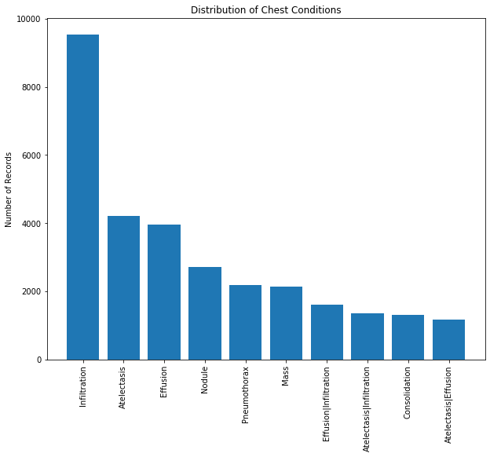

```python
# Evaluate distribution of conditions.  Observe a highly imbalanced dataset.  Remove records with 'No Finding' label
data_labels = data_labels[data_labels['No Finding']==0]

def show_dist(df, colname, n):
    counts = df[colname].value_counts()[:n]

    x_val = range(n)
    fig, ax = plt.subplots(1, 1, figsize=(10,8))
    ax.bar(x_val, counts)
    ax.set_xticks(x_val)
    ax.set_xticklabels(counts.index, rotation=90)
    plt.title('Distribution of Chest Conditions')
    plt.ylabel('Number of Records')
    return None

show_dist(data_labels, 'Finding Labels', 10)
```

```python
# Drop 'No Finding' column--no longer relevant
data_labels.drop(labels=['No Finding'], axis=1, inplace=True)
data_labels.info()
```

```
<class 'pandas.core.frame.DataFrame'>
Int64Index: 51751 entries, 0 to 112115
Data columns (total 26 columns):
Image Index                    51751 non-null object
Finding Labels                 51751 non-null object
Follow-up #                    51751 non-null int64
Patient ID                     51751 non-null int64
Patient Age                    51751 non-null int64
Patient Gender                 51751 non-null object
View Position                  51751 non-null object
OriginalImage[Width            51751 non-null int64
Height]                        51751 non-null int64
OriginalImagePixelSpacing[x    51751 non-null float64
y]                             51751 non-null float64
Unnamed: 11                    0 non-null float64
Atelectasis                    51751 non-null int64
Cardiomegaly                   51751 non-null int64
Consolidation                  51751 non-null int64
Edema                          51751 non-null int64
Effusion                       51751 non-null int64
Emphysema                      51751 non-null int64
Fibrosis                       51751 non-null int64
Hernia                         51751 non-null int64
Infiltration                   51751 non-null int64
Mass                           51751 non-null int64
Nodule                         51751 non-null int64
Pleural_Thickening             51751 non-null int64
Pneumonia                      51751 non-null int64
Pneumothorax                   51751 non-null int64
dtypes: float64(3), int64(19), object(4)
memory usage: 10.7+ MB
```

```python
all_conditions = get_conditions(data_labels)
all_conditions
```

```
array(['Atelectasis', 'Cardiomegaly', 'Consolidation', 'Edema',
       'Effusion', 'Emphysema', 'Fibrosis', 'Hernia', 'Infiltration',
       'Mass', 'Nodule', 'Pleural_Thickening', 'Pneumonia',
       'Pneumothorax'], dtype='<U18')
```

```python
data_labels['conditions'] = data_labels[all_conditions].values.tolist()
```

## Data Preparation

```python
# Create mapping from image names to file paths
path_pattern = os.path.join('data', 'images_*', 'images', '*.png')
img_path_list = glob.glob(path_pattern)
img_path_dict = {os.path.basename(img_path): img_path for img_path in img_path_list}
```

```python
# Add image path for each record in dataset
data_labels['img_path'] = data_labels['Image Index'].map(lambda img_name: img_path_dict[img_name])
```

```python
# Split data into training, validation, and test sets
train_data, test_data = train_test_split(data_labels, test_size=0.1, shuffle=True,
                                        stratify = data_labels['Finding Labels'].map(lambda x: x[:3]))
```

```python
train_data, val_data = train_test_split(train_data, test_size=0.2, shuffle=True,
                                       stratify = train_data['Finding Labels'].map(lambda x: x[:3]))
```

```python
print('Train data dimensions:', train_data.shape)
print('Validation data dimensions:', val_data.shape)
print('Test data dimensions:', test_data.shape)
```

```
Train data dimensions: (37260, 28)
Validation data dimensions: (9315, 28)
Test data dimensions: (5176, 28)
```

### Data Generator Setup

```python
# Create data generator to read images in batches
all_conditions = list(all_conditions)
IMG_SIZE=(256, 256)
datagen = ImageDataGenerator()

train_datagen = datagen.flow_from_dataframe(train_data,
                                           x_col='img_path',
                                           y_col=all_conditions,
                                           target_size=IMG_SIZE,
                                           class_mode='raw',
                                           batch_size=32)

val_datagen = datagen.flow_from_dataframe(val_data,
                                          x_col='img_path',
                                          y_col=all_conditions,
                                          target_size=IMG_SIZE,
                                          class_mode='raw',
                                          batch_size=64)

test_datagen = datagen.flow_from_dataframe(test_data,
                                           x_col='img_path',
                                           y_col=all_conditions,
                                           target_size=IMG_SIZE,
                                           class_mode='raw',
                                           batch_size=1024)
```

```
Found 37260 validated image filenames.
Found 9315 validated image filenames.
Found 5176 validated image filenames.
```

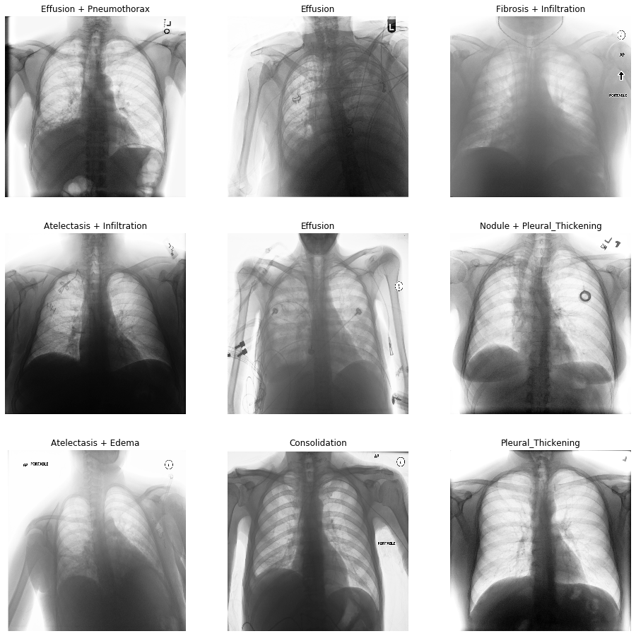

```python
# Visualize first batch of images
train_batch = next(train_datagen)[:9]

fig, axs = plt.subplots(3,3, figsize=(16,16))
axs = axs.flatten()

for (img_x, img_y, img_ax) in zip(train_x, train_y, axs):
    img_ax.imshow(img_x[:,:,0], cmap='Greys')
    img_x_labels = ' + '.join([cond for cond, label in zip(all_conditions, img_y) if label==1])
    img_ax.set_title(img_x_labels)
    img_ax.axis('off')
```

## Build Models

### CNN

```python
# Define optimizer
opt = keras.optimizers.adam_v2.Adam(learning_rate=0.001)
topk = keras.metrics.TopKCategoricalAccuracy(k=5)
```

```python
model = keras.models.Sequential()
model.add(keras.layers.Conv2D(32, (3,3), activation='relu', padding='same',
                                input_shape=(train_x.shape[1:])))
model.add(keras.layers.MaxPool2D((2,2), strides=2))
model.add(keras.layers.Conv2D(64, (3,3), activation='relu', padding='same'))
model.add(keras.layers.MaxPool2D((2,2), strides=2))
model.add(keras.layers.Conv2D(128, (3,3), activation='relu', padding='same'))
model.add(keras.layers.MaxPool2D((2,2), strides=2))
model.add(keras.layers.Conv2D(256, (3,3), activation='relu', padding='same'))
model.add(keras.layers.MaxPool2D((2,2), strides=2))
model.add(keras.layers.Flatten())
model.add(keras.layers.Dense(len(all_conditions), activation='sigmoid'))
print(model.summary())
```

```
Model: "sequential_12"
_________________________________________________________________
Layer (type)                 Output Shape              Param #
=================================================================
conv2d_46 (Conv2D)           (None, 256, 256, 32)      896
_________________________________________________________________
max_pooling2d_46 (MaxPooling (None, 128, 128, 32)      0
_________________________________________________________________
conv2d_47 (Conv2D)           (None, 128, 128, 64)      18496
_________________________________________________________________
max_pooling2d_47 (MaxPooling (None, 64, 64, 64)        0
_________________________________________________________________
conv2d_48 (Conv2D)           (None, 64, 64, 128)       73856
_________________________________________________________________
max_pooling2d_48 (MaxPooling (None, 32, 32, 128)       0
_________________________________________________________________
conv2d_49 (Conv2D)           (None, 32, 32, 256)       295168
_________________________________________________________________
max_pooling2d_49 (MaxPooling (None, 16, 16, 256)       0
_________________________________________________________________
flatten_11 (Flatten)         (None, 65536)             0
_________________________________________________________________
dense_12 (Dense)             (None, 14)                917518
=================================================================
Total params: 1,305,934
Trainable params: 1,305,934
Non-trainable params: 0
_________________________________________________________________
None
```

```python
model.compile(optimizer=opt, loss='binary_crossentropy', metrics=[topk])
```

```python
# Run for 2 epochs to conserve computing resources
history = model.fit(train_datagen,
                    steps_per_epoch=100,
                    validation_steps=50,
                    validation_data=val_datagen,
                    epochs=2)
```

```python
test_x, test_y = next(test_datagen)
```

## Model Evaluation

```python
# Predict model
y_pred = model.predict(test_x)
```

```python
y_pred[:5]
```

```
array([[0.20166901, 0.07214871, 0.05906156, 0.02727956, 0.30680323,
        0.01325548, 0.06997937, 0.0037351 , 0.25562257, 0.20107701,
        0.12394708, 0.10428512, 0.01202098, 0.14555046],
       [0.24328488, 0.10327926, 0.08492112, 0.0667983 , 0.33003476,
        0.0241212 , 0.02279302, 0.0064249 , 0.33249992, 0.10642788,
        0.09942654, 0.05880937, 0.02358162, 0.06386936],
       [0.25620204, 0.05903396, 0.10174575, 0.04916012, 0.24418822,
        0.06929016, 0.0540528 , 0.01102525, 0.32861528, 0.19259602,
        0.17040068, 0.09244871, 0.03352752, 0.08919248],
       [0.17195037, 0.03534457, 0.14248595, 0.04134786, 0.28238672,
        0.05141163, 0.01547927, 0.00231597, 0.3844045 , 0.11465839,
        0.11554116, 0.06628197, 0.01883331, 0.04506251],
       [0.29151464, 0.06840333, 0.08437636, 0.04442558, 0.2645261 ,
        0.06935498, 0.04514971, 0.00934643, 0.36389688, 0.1545091 ,
        0.14699984, 0.09233651, 0.03074557, 0.09404346]], dtype=float32)
```

```python
x = range(len(all_conditions))

# Proportion of conditions predicted by model
pred_prop = np.mean(y_pred, axis=0)

# Actual proportion of conditions in test data
actual_prop = np.mean(test_y, axis=0)
```

```python
# Smooth distribution curve
x_new = np.arange(0, len(all_conditions) - 1, 0.1)

interp_pred = interp1d(x, pred_prop, kind=2)
interp_actual = interp1d(x, actual_prop, kind=2)

pred_prop_interp = interp_pred(x_new)
actual_prop_interp = interp_actual(x_new)
```

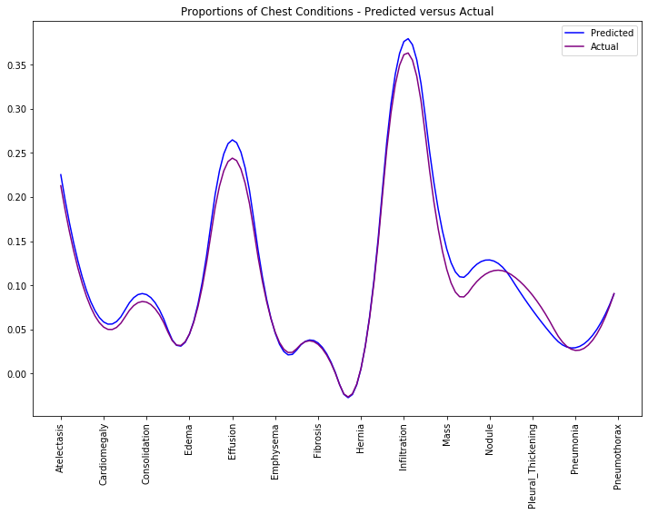

```python
# Plot distributions
fig, ax = plt.subplots(1, 1, figsize=(12,8))

ax.plot(x_new, pred_prop_interp, c='blue', label='Predicted')
ax.plot(x_new, actual_prop_interp, c='purple', label='Actual')
ax.set_title('Proportions of Chest Conditions - Predicted versus Actual')
ax.set_xticks(range(len(all_conditions)))
ax.set_xticklabels(all_conditions, rotation=90)
ax.legend()
plt.show()
```

## Retrospective - Observed Challenges and Potential Improvements

Observed challenges:

- Multilabel classification metrics - metrics that accurately represent performance in multilabel classification problems are difficult to derive and implement. Each patient (and hence X-ray) may have multiple conditions, so there will often be scenarios of partial correctness where most but not all of the true and predicted labels match.
- Labeling accuracy - Labels are extracted from physician notes via NLP methods and may not be entirely accurate.
- Computing resource limitations - CNNs require large amounts of RAM and processing power to run efficiently. Training iterations (i.e., epochs) were constrained.

Areas for additional improvement/exploration:

- Add new relevant features to model - X-ray image data can be supplemented by factors like patient age, gender, and medical history in predicting patient conditions.
- Resampling to mitigate class imbalance - Because of the rarity of some conditions (e.g., hernia), the dataset is very imbalanced and can result in training issues. The data can be resampled to increase weights of rare conditions and decrease weights of common conditions.